# ECON 6114 - R Programming (Code Supplement)

# Week 2 Programming Supplement

This document contains code that was too long to display in the week’s slides. Unlike code in the slides, all examples below are executed so you can see the values.

You should use these programming supplements to follow along and try executing the example code yourself.

## I. Review and Catchup

### Looping with lapply

R’s `*apply` family of functions are a bit difficult to understand at first, but soon you’ll come to love them. They make your code more expressive, flexible, and parallelizable (more on that final point later). One of the most popular is `lapply` (“list apply”), which loops over a thing (e.g. vector, list) and returns a 1-level list. Let’s try it out:

```r
# Get some data
data("ChickWeight")
weights <- ChickWeight$weight

# Loop over and encode "above mean" and "below mean"
the_mean <- mean(weights)
meanCheck <- function(val, ref_mean){
    if (val > ref_mean){return("above mean")}
    if (val < ref_mean){return("below mean")}
    return("equal to the mean")
}
check_vec <- lapply(weights, FUN = function(x){meanCheck(val = x, ref_mean = the_mean)})
```

```r
# Check it out
str(check_vec, max.level = 1)
```

[output not shown]

### Looping with sapply

On the previous slide, you saw how to loop over a vector/list and get back a list of function results. This may not be appropriate for some settings. Remember that you cannot execute statistical operations like `mean` over a list. For that, we’d probably prefer to have a *vector* of results. This is where R’s `sapply` (“simplified apply”) comes in. `sapply` works the same way that `lapply` does but returns a vector. Try it for yourself:

```r
# Get some data
data("ChickWeight")
weights <- ChickWeight$weight

# Loop over and encode "above mean" and "below mean"
the_mean <- mean(weights)
meanCheck <- function(val, ref_mean){
    if (val > ref_mean){return("above mean")}
    if (val < ref_mean){return("below mean")}
    return("equal to the mean")
}
check_vec <- sapply(weights, FUN = function(x){meanCheck(val = x, ref_mean = the_mean)})
```

### Looping with apply

When analyzing real-world datasets, you may want to use the same looping convention we’ve been discussing, but apply it over many items and the get some summary (such as the median) of the results. This is where R’s `apply` function comes in! Check it out

```r
# Get some data
data("ChickWeight")

# Calculate column-wise range
cwRanges <- apply(ChickWeight, MARGIN = 2, FUN = function(x){range(as.numeric(x))})

# Calculate row-wise range
rwRanges <- apply(ChickWeight, MARGIN = 1, FUN = function(blah){range(as.numeric(blah))})
```

## Subsetting

### Subsetting Vectors

**Subsetting** is the act of retrieving a portion of an object, usually based on some logical condition (e.g. “all elements greater than 5”). In R, this is done with the `[` operator.

```r
# Create a vector to work with
myVec <- c(var1 = 10, var2 = 15, var3 = 20, av4 = 6)

# "the first element"
myVec[1]
```

```
## var1
##   10
```

```r
# "second to fourth elements"
myVec[2:4]
```

```
## var2 var3  av4
##   15   20    6
```

```r
# "the element named var3"
myVec["var3"]
```

```
## var3
##   20
```

### Subsetting Lists

Lists, arbitrary collections of (potentially heterogeneous) R objects, are subsetted a bit differently than vectors. If you use `[` with a list, you are guaranteed to get back another list. If you use `[[`, you will get back an object in its natural form (whatever it would look like if it wasn’t in the list). You can also use `$` to access named elements.

```r
# Set up a sample list object
someList <- list(country = "DEU",
                 region  = "EU",
                 econ_stats = list(gdp_growth = 1.5,
                                   rm10y      = 2.75,
                                   DAXmonthly = c(1000, 1100, 1050, 1200, 1500)))

# Examine the list structure
str(someList)
```

```
## List of 3
##  $ country   : chr "DEU"
##  $ region    : chr "EU"
##  $ econ_stats:List of 3
##   ..$ gdp_growth: num 1.5
##   ..$ rm10y     : num 2.75
##   ..$ DAXmonthly: num [1:5] 1000 1100 1050 1200 1500
```

```r
# Grab the country name
country1 <- someList[["country"]]
country2 <- someList$country

class(country1)
```

```
## [1] "character"
```

```r
class(country2)
```

```
## [1] "character"
```

```r
identical(country1, country2)
```

```
## [1] TRUE
```

```r
# Grab the economic stats as a list within a list
germanyStats <- someList["econ_stats"]
class(germanyStats)
```

```
## [1] "list"
```

```r
# Grab the numeric vector of stock prices
daxPrices <- someList$econ_stats$DAXmonthly
class(daxPrices)
```

```
## [1] "numeric"
```

```r
# Another way to parse down the list for stock prices
someList[["econ_stats"]][["DAXmonthly"]]
```

```
## [1] 1000 1100 1050 1200 1500
```

### Subsetting Dataframes

Data frames are the workhorse data structure of statistics in R. The best way to learn data frame subsetting is to just walk through the examples below:

```r
# Create a data frame
someDF <- data.frame(conference  = c("Big East", "Big Ten", "Big East", "ACC", "SEC"),
                     school_name = c("Villanova", "Minnesota", "Marquette", "Duke", "LSU"),
                     wins        = c(18, 14, 19, 24, 12),
                     ppg         = c(71.5, 45.8, 66.9, 83.4, 58.7))

# Grab the wins column (NOTE: will give you back a vector)
someDF[, "wins"]
```

```
## [1] 18 14 19 24 12
```

```r
someDF[["wins"]]
```

```
## [1] 18 14 19 24 12
```

```r
# Grab conference and wins columns
someDF[, c("conference", "wins")]
```

```
##   conference wins
## 1   Big East   18
## 2    Big Ten   14
## 3   Big East   19
## 4        ACC   24
## 5        SEC   12
```

```r
# Grab the first 3 rows and the two numeric columns
someDF[1:3, c("wins", "ppg")]
```

```
##   wins  ppg
## 1   18 71.5
## 2   14 45.8
## 3   19 66.9
```

### Using Logical Vectors

So far, we’ve seen how to subset R objects using numeric indices and named elements. These are useful approaches, but both require you to know something about the contents of the obejct you’re working with.

Using these methods (especially numeric indices like saying *give me columns 2-4*) can make your code confusing and hard for others to reason about. Wherever possible, I strongly recommend using logical vectors for subsetting. This makes your code intuitive and more flexible to change.

```r
# Some dataframe
playerDF <- data.frame(
    playerName   = c("Rajon Rondo", "Paul Pierce", "Kevin Garnett", "Ray Allen", "Big Baby")
    , position   = c("PG", "SF", "PF", "SG", "C")
    , apg        = c(14.2, 3.5, 4.6, 5.0, 0.7)
    , ppg        = c(4.8, 31.0, 24.6, 33.2, 12.3)
    , fg_percent = c(-.062, 0.48, 0.63, 0.80, 0.51)
)

# "Give me a dataframe with all Rondo and KG's stats"
nameIndex <- playerDF$playerName %in% c("Rajon Rondo", "Kevin Garnett")
nameIndex
```

```
## [1]  TRUE FALSE  TRUE FALSE FALSE
```

```r
class(nameIndex)
```

```
## [1] "logical"
```

```r
playerDF[nameIndex,]
```

```
##      playerName position  apg  ppg fg_percent
## 1   Rajon Rondo       PG 14.2  4.8     -0.062
## 3 Kevin Garnett       PF  4.6 24.6      0.630
```

```r
# "Give me apg for players who averaged more than 20 ppg"
playerDF[playerDF$ppg > 20, c("playerName", "apg")]
```

```
##      playerName apg
## 2   Paul Pierce 3.5
## 3 Kevin Garnett 4.6
## 4     Ray Allen 5.0
```

```r
# "Give me stats for all the guards""
guardIndex <- grepl("G$", playerDF$position)
print(guardIndex)
```

```
## [1]  TRUE FALSE FALSE  TRUE FALSE
```

```r
playerDF[grepl("G$", playerDF$position)]
```

```
##      playerName  ppg
## 1   Rajon Rondo  4.8
## 2   Paul Pierce 31.0
## 3 Kevin Garnett 24.6
## 4     Ray Allen 33.2
## 5      Big Baby 12.3
```

```r
# "Give me stats for players who were guards OR show above 50% from the field"
playerDF[grepl("G$", playerDF$position) | playerDF$fg_percent > 0.5,]
```

```
##      playerName position  apg  ppg fg_percent
## 1   Rajon Rondo       PG 14.2  4.8     -0.062
## 3 Kevin Garnett       PF  4.6 24.6      0.630
## 4     Ray Allen       SG  5.0 33.2      0.800
## 5      Big Baby        C  0.7 12.3      0.510
```

```r
# "Give me the column names that start with p"
names(playerDF)[grepl("^p", names(playerDF))]
```

```
## [1] "playerName" "position"   "ppg"
```

## Debugging Strategies

### Print Debugging

As you’ve probably already learned, writing code involves a never-ending process of trying this, fixing errors, trying other things, fixing new errors, etc. The process of identifying and fixing errors/bugs is called **debugging**.

The simplest way to debug an issue in your code is to use **print debugging**. This approach involves forming expectations about the state of the objects in your environment at each point in your code, then printing those states at each point to find where things broke.

```r
# This function is supposed to sum all the numbers in a vector that are greater than 10
# but it's breaking with a weird error. Let's use print debugging to dig into it
sumBigNums <- function(aVector){
    running_sum <- 0
    for (num in aVector){
        if (num >= 10){
            running_sum <- running_sum + num
        }
    }
    return(running_sum)
}

# This should return 45...hmmmmmm
some_vector <- c(11, 20, 5, 9.5, 10, 14)
sumBigNums(some_vector)
```

```
## [1] 55
```

```r
# Let's refactor this function (change the code) and print the status at each stage
sumBigNums <- function(aVector){
    running_sum <- 0
    for (num in aVector){
        # Grab the sum before we hit this number
        sum_before <- running_sum

        # If the number if greater than 10, increase the sum
        if (num >= 10){
            running_sum <- running_sum + num
        }

        # print new state of the environment
        print(paste0("num: ", num, " | before: ", sum_before, " | after: ", running_sum))
    }
    return(running_sum)
}

# Run the code again and look at the output...it looks like we added the number
# 10 to the count even though it isn't greater than 10! We need to change
# the code to say "num > 10", not ">="
sumBigNums(some_vector)
```

```
## [1] "num: 11 | before: 0 | after: 11"
## [1] "num: 20 | before: 11 | after: 31"
## [1] "num: 5 | before: 31 | after: 31"
## [1] "num: 9.5 | before: 31 | after: 31"
## [1] "num: 10 | before: 31 | after: 41"
## [1] "num: 14 | before: 41 | after: 55"
```

```
## [1] 55
```

## Installing and Using External Packages

### Loading Installed Packages

```r
# Load dependencies
library(data.table)
library(quantmod)
library(rbokeh)

# Get data and plot it
quantmod::getSymbols('CPIAUCSL', src = 'FRED')
```

```
## [1] "CPIAUCSL"
```

```r
cpiDT <- data.table::data.table(
    CPIAUCSL
    , keep.rownames = TRUE
)

# Plot it!
rbokeh::figure(
    data = cpiDT
    , title = "U.S. CPI"
    , ylab = "Index (1982-1984 = 100)"
    , xlab = "date"
) %>% ly_lines(x = cpiDT$index, y = cpiDT$CPIAUCSL, color = "blue")
```

[interactive chart not shown]

## V. User-defined Functions

### UDF Example

You can you user-defined functions to wrap arbitrarily complicated logic into concise statements. As mentioned in week 1, a good rule of thumb is to say “any time your find yourself copying and pasting the same code more than twice, write a function”.

```r
# Given a number between 0 and 1, multiply by a random number
# between 0 and 1, then return an action based on quantile
weirdFunction <- function(num){
    rand_num    <- runif(n = 1, min = 0, max = 1)
    action_val  <- num*rand_num
    if (action_val <= 0.25){return("left")}
    if (action_val <= 0.5){return("right")}
    if (action_val <= 0.75){return("up")}
    return("down")
}
action_sequence <- sapply(runif(n = 100, min = 0, max = 1), weirdFunction)
action_sequence[1:20]
```

```
##  [1] "right" "left"  "left"  "left"  "left"  "left"  "left"  "left"
##  [9] "left"  "left"  "right" "up"    "left"  "up"    "left"  "right"
## [17] "left"  "left"  "left"  "left"
```

### Functions That Return Stuff

As you’ve seen in previous examples, the R special word `return` tells a function to “give back” some value. When you execute an expression like `x <- someFunction()`, that function’s return value (an R object) is stored a variable called “x”.

Unlike in some other programming languages, R allows you to use multiple `return` values inside the body of a function. The first time that the code inside the function reaches a `return` value, it will pass that value back out of the function and immediately stop executing the function.

```r
# simple function + print debugging
simpFunction <- function(n){
    print("first print")
    if (n > 5){return(TRUE)}

    print("second print")
    if (n < 5){return(FALSE)}

    print("third print")
    return("TRALSE")
}

simpFunction(100)
```

```
## [1] "first print"
```

```
## [1] TRUE
```

```r
simpFunction(5)
```

```
## [1] "first print"
## [1] "second print"
## [1] "third print"
```

```
## [1] "TRALSE"
```

### Functions That Return Nothing

Not all functions have to return something! Sometimes you may want to create a function that just has some side effect like creating a plot, writing to a file, or print to the console.

These are called “null functions” and they’re common in scripting languages like R. By default, these functions return the R special value `NULL`.

```r
printSentence <- function(theSentence){
    words <- strsplit(x = theSentence, split = " ")
    for (word in words){
        print(word)
    }
}

# Assigning to an object is irrelevant...this function doesn't return anything
x <- printSentence("Hip means to know, it's a form of intelligence")
```

```
## [1] "Hip"          "means"        "to"           "know,"
## [5] "it's"         "a"            "form"         "of"
## [9] "intelligence"
```

```r
x
```

[output not shown]

### Brief Review of Scoping

Remember when we talked about namespaces and how R searches for objects? It’s time to extend that logic to functions…which is where things get a bit weird and hard to understand.

R uses a search technique called lexical scoping

```r
# Define an object + function in the global environment
x <- 4
someFunc <- function(x){
    return(x^2)
}

# If you call someFunc without an argument, it will go up one environment and look
# for "X" in the global environment
someFunc(x)
```

```
## [1] 16
```

```r
# If you pass in a new value, it will use that instead. Note that the value of
# x in the global environment remains unchanged.
someFunc(x = 6)
```

```
## [1] 36
```

```r
x
```

```
## [1] 4
```

### Sourcing Helper Functions

In the examples so far, I’ve been defining functions and using them in the same breath. As your projects grow in complexity, you will find this really tedious and hard to keep track of.

An alternative that many intermediate R programmers turn to is defining one or more `helperfuns.R` scripts to store custom functions and then using `source()` at the top of their run scripts to make those functions available in the main program.

Let’s create two scripts.

**script 1: helperfuns.R**

```r
# Define some arbitrary custom function
myFunction <- function(n){
    if (n <= 5){
        return(n^2)
    } else {
        return(n^3)
    }
}
```

**script 2: run_script.R**

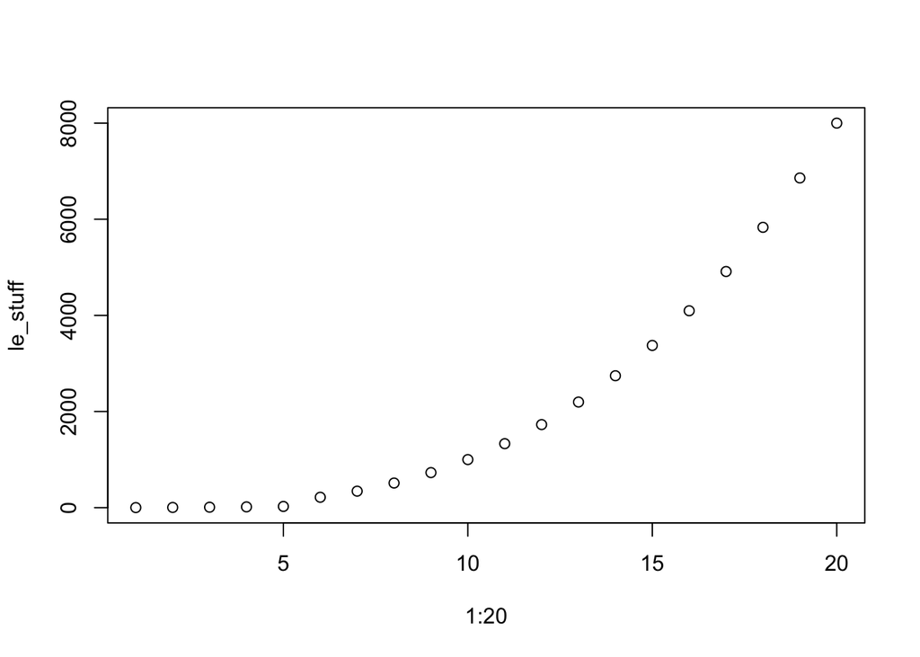

```r
# uncomment the line below to source in the helper functions file
#source("helperfuns.R")

# Apply that function over some data
le_stuff <- sapply(c(1:20), myFunction)

# Plot the result
plot(x = 1:20, y = le_stuff)
```

## Working with Files

### Semi-Structured: JSON Files

JSON ([JavaScript Object Notation](http://www.json.org/)) is a light-weight format for representing arbitrary data objects in text files. It is used by many applications and most programming languages have functionality to handle and parse it.

Let’s try an example with data from the state of Oregon. The following link returns data on boating access sites in the state of Oregon. Try pasting it into your browser.

https://data.oregon.gov/api/views/t6bs-tkn4/rows.json?accessType=DOWNLOAD

We can download the data and parse it into an R list object using the `jsonlite` package:

```r
library(jsonlite)

# Go get some data
result <- jsonlite::fromJSON("https://data.oregon.gov/api/views/t6bs-tkn4/rows.json")

# Check it out. Pass the max.level argument to the list to tell R how deep into it you want to go
str(result, max.level = 1)
```

```
## List of 2
##  $ meta:List of 1
##  $ data:List of 883
```

```r
# Check out the "meta$view element"
str(result[["meta"]][["view"]], max.level = 1)
```

```
## List of 39
##  $ id                      : chr "t6bs-tkn4"
##  $ name                    : chr "Oregon's Boating Access Sites"
##  $ attribution             : chr "Oregon State Marine Board"
##  $ attributionLink         : chr "http://www.boatoregon.com"
##  $ averageRating           : int 0
##  $ category                : chr "Recreation"
##  $ createdAt               : int 1317055887
##  $ description             : chr "Find a boat ramp in a location near you! Hundreds of boating access points, amenities, and launch information i"| __truncated__
##  $ displayType             : chr "map"
##  $ downloadCount           : int 1351
##  $ hideFromCatalog         : logi FALSE
##  $ hideFromDataJson        : logi FALSE
##  $ indexUpdatedAt          : int 1453848229
##  $ newBackend              : logi FALSE
```

[output cut: 25 more lines]

### Unstructured: Text files

In the context of statistical programming, text files that are “unstructured” are those that do not have an obvious parallel in a data object like a data frame, vector, list, or key-value store. An example might be a large archive of tweets or a collection of court transcripts.

Working with these types of files typically involves reading them into R line-by line and then using something called [regular expression](https://stat.ethz.ch/R-manual/R-devel/library/base/html/regex.html)(basically just pattern-matching on strings) to extract relevant features like word counts. For example:

```r
# Parameters
shakespeare_text <- "https://ocw.mit.edu/ans7870/6/6.006/s08/lecturenotes/files/t8.shakespeare.txt"

# Read all the text into a vector (one line per element)
text_vec <- readLines(con = shakespeare_text)

# Examine a few random lines:
sample(text_vec, 5)
```

```
## [1] "    't, and I have a disguise to sound Falstaff. If I find her"
## [2] "  LAUNCELOT. The old proverb is very well parted between my master"
## [3] "    bellow for revenge."
## [4] "DUKE. Come, stand by me; fear nothing. Guard with halberds."
## [5] "    This honourable bounty shall belong."
```

```r
# Coerce everything to lower-case
text_vec <- tolower(text_vec)

# Grab just the lines with the word "thou" or "twas""
thou_art_my_vector <- text_vec[grepl(pattern = "thou|twas", text_vec)]

# Print the count of lines w/ those words
lines_with_fancy_words <- length(thou_art_my_vector)
thing_to_print <- paste0(
    "of the "
    , length(text_vec)
    , " lines of text in the complete works of William Shakespeare, only "
    , lines_with_fancy_words
    , " used thou or twas."
)
print(thing_to_print)
```

```
## [1] "of the 124456 lines of text in the complete works of William Shakespeare, only 7247 used thou or twas."
```